# Script para calcular biomasa del arbolado en CU (fase 4)

Viacheslav Shalisko

25 de octubre de 2016

# Árboles en los Centros Universitarios

## —————————————————————————

This program is free software; you can redistribute it and/or modify it under the terms of the GNU General Public License as published by the Free Software Foundation; either version 2 of the License, or (at your option) any later version.

This program is distributed in the hope that it will be useful, but WITHOUT ANY WARRANTY; without even the implied warranty of MERCHANTABILITY or FITNESS FOR A PARTICULAR PURPOSE. See the GNU General Public License for more details.

## —————————————————————————

### Nota: fase 4 del censo (CUNORTE y CUVALLES)

### Formato de tabla de entrada (.csv):

1. *Centro* - código del CU
2. *Especie* - nombre científico
3. *Codigo* - identificador único del arbol
4. *AB* - área basal del árbol (dm<sup>2</sup>)
5. *DTr* - diametro del tronco equivalente (cm)
6. *Alt* - estatura del árbol (m)  
   Columnas posteriores a la sexta no se incluyen en el análisis y pueden contener cualquier información

### Definición de variables

```r
# Tabla de datos fuente en el formato .csv
tabla_fuente <- "Censo_4.csv"

tabla_especies <- "Censo_4_formulas.csv"

# nombre de una subcarpeta donde se van a guardar las tablas con resultados (carpeta debe existir)
output_path <- 'resultados_fase4'
# prefijo de nombres de archivo de tablas con resultados
output_basename <- 'tabla_fase_4_biomasa'
```

### Definición de funciones genéricas

```r
simpleCap <- function (x) {
  paste(toupper(substr(x, 1, 1)), tolower(substr(x, 2, nchar(x))), sep="")
}
trim <- function (x) gsub("^\\s+|\\s+$", "", x)
```

## Cargar los datos

```r
arboles <- read.csv(tabla_fuente)
formulasB <- read.csv(tabla_especies)

arboles[,"Centro"] <- as.factor(arboles[,"Centro"])
arboles[,2] <- sapply(as.character(arboles[,2]), simpleCap) # Primera letra mayuscula otras minusculas
arboles[,2] <- as.factor(trim(arboles[,2]))

list_centers <- unique(arboles[,"Centro"], incomparables = FALSE)
list_species <- unique(arboles[,2], incomparables = FALSE)
```

## Resumen de los datos

#### Nota: Las ecuaciones alométricas se cargan del archivo definido en variable `tabla_especies` y se almacenan en el vector `formulasB`

```r
dim(arboles)
```

```
## [1] 1998    9
```

```r
arboles_my <- arboles[,c(1:3,4:6)]
names(arboles_my) <- c("Centro","Especie","Clave_arbol","AB","DAP","H")
summary(arboles_my)
```

```
##       Centro                       Especie       Clave_arbol
##  CUNORTE :1109   Prosopis laevigata    :698   C14-5-1  :   1
##  CUVALLES: 889   Cupressus sempervirens:208   C14-5-10 :   1
##                  Salix humboldtiana    :201   C14-5-100:   1
##                  Salix bonplandiana    :185   C14-5-101:   1
##                  Ficus benjamina       :114   C14-5-102:   1
##                  Acacia schaffneri     : 86   C14-5-103:   1
##                  (Other)               :506   (Other)  :1992
##        AB               DAP               H
##  Min.   :  0.200   Min.   :  5.00   Min.   : 1.300
##  1st Qu.:  0.660   1st Qu.:  9.20   1st Qu.: 4.000
##  Median :  1.515   Median : 13.90   Median : 5.000
##  Mean   :  3.911   Mean   : 17.92   Mean   : 5.347
##  3rd Qu.:  3.917   3rd Qu.: 22.30   3rd Qu.: 6.300
##  Max.   :164.800   Max.   :144.90   Max.   :19.600
##
```

```r
sort(list_centers)
```

```
## [1] CUNORTE  CUVALLES
## Levels: CUNORTE CUVALLES
```

```r
list_species <- sort(list_species)
list_species
```

```
##  [1] Acacia aff. constricta       Acacia farnesiana
##  [3] Acacia pennatula             Acacia schaffneri
##  [5] Araucaria heterophylla       Arecastrum romanzoffianum
##  [7] Bauhinia variegata           Bucida buceras
##  [9] Buddleja parviflora          Bursera fagaroides
## [11] Callistemon aff. salignus    Callistemon viminalis
## [13] Cascabela thevetioides       Casimiroa edulis
## [15] Casuarina equisetifolia      Cedrela odorata
## [17] Ceiba speciosa               Citrus × aurantiifolia
## [19] Cupressus lusitanica         Cupressus macrocarpa
## [21] Cupressus sempervirens       Desconocida #5
## [23] Dypsis lutescens             Ehretia tinifolia
## [25] Eriobotrya japonica          Eucalyptus camaldulensis
## [27] Eugenia sp.                  Eysenhardtia polystachya
## [29] Ficus benjamina              Ficus crocata
```

[output cut: 17 more lines]

```r
summary(formulasB)
```

```
##                       Especie
##  Acacia aff. constricta   : 1
##  Acacia farnesiana        : 1
##  Acacia pennatula         : 1
##  Acacia schaffneri        : 1
##  Araucaria heterophylla   : 1
##  Arecastrum romanzoffianum: 1
##  (Other)                  :75
##                                            Formula
##  exp(-3.282+0.95*log((DAP^2)*H))               :45
##  exp(-6.3789-0.877*log(1/(DAP^2))+2.151*log(H)): 8
##  0.0421*(((DAP^2)*H)^0.944)                    : 6
##  430*(0.0344+0.00003*(DAP^2)*H)                : 4
##  (0.4/0.65)*exp(-3.282+0.95*log((DAP^2)*H))    : 3
##  2*0.0192922*(((DAP^2)*H)^0.9392)              : 2
##  (Other)                                       :13
```

## Calcular biomasa de arboles

```r
tabla_biomasas <- data.frame(
                 Centro=factor(),Especie=factor(),Clave_arbol=character(),
                 AB=numeric(),DAP=numeric(),H=numeric(),
                 biomasa=numeric(),C=numeric(),CO2=numeric())

for (i in 1:length(list_species)) {
  registros <- arboles_my[arboles_my$Especie == list_species[i],]
  formulaB <- formulasB[as.character(formulasB$Especie) == as.character(list_species[i]),]

  DAP <- registros$DAP
  H <- registros$H
  cat("\n\n")
  print(as.character(list_species[i]))
  formulaBeval <- parse(text=as.character(formulaB$Formula))
  cat(paste("Formula: ",formulaBeval,"\n"))

  # biomasa en kg
  biomasa <- eval(formulaBeval)
  # carbono en kg
  C <- 0.5 * biomasa
  # CO2 en kg
  CO2 <- 3.67 * C

  registros <- cbind(registros,biomasa,C,CO2)
  print(registros[,c(1:2,4:7,9)])
  tabla_biomasas <- rbind(tabla_biomasas,registros)
}
```

```
##
##
## [1] "Acacia aff. constricta"
## Formula:  exp(-3.282 + 0.95 * log((DAP^2) * H))
##      Centro                Especie   AB DAP   H  biomasa      CO2
## 704 CUNORTE Acacia aff. constricta 0.53 8.2 2.4 4.699942 8.624394
##
##
## [1] "Acacia farnesiana"
## Formula:  exp(-3.282 + 0.95 * log((DAP^2) * H))
##        Centro           Especie   AB  DAP   H   biomasa       CO2
## 201   CUNORTE Acacia farnesiana 1.45 13.6 3.9 19.493096 35.769830
## 496   CUNORTE Acacia farnesiana 0.33  6.5 3.0  3.736337  6.856179
## 516   CUNORTE Acacia farnesiana 1.39 13.3 5.6 26.347672 48.347979
## 610   CUNORTE Acacia farnesiana 0.20  5.1 3.6  2.802310  5.142239
```

[output cut: 2310 more lines]

## Guardar tabla con biomasas calculadas

```r
tabla_biomass_filename <- paste(output_path,paste(output_basename,"resultados.csv",sep=""),sep="/")
write.table(tabla_biomasas, file = tabla_biomass_filename, sep = ",", row.names = FALSE)
```

## Representar grgáficamente los modelos allometricos

```r
library(RColorBrewer)
```

```
##
## [1] "Acacia aff. constricta"
## Formula:  exp(-3.282 + 0.95 * log((DAP^2) * H))
```

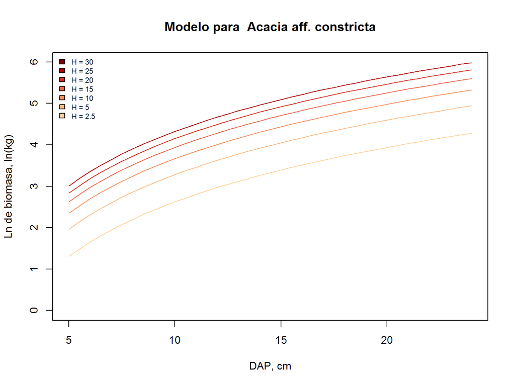

```
##
## [1] "Acacia farnesiana"
## Formula:  exp(-3.282 + 0.95 * log((DAP^2) * H))
```

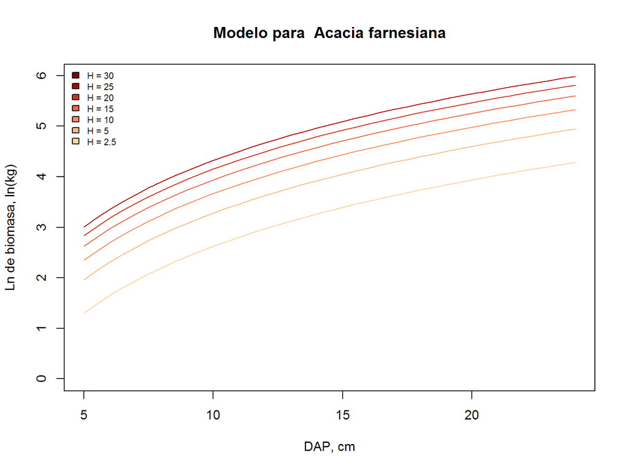

```
##
## [1] "Acacia pennatula"
## Formula:  exp(-3.282 + 0.95 * log((DAP^2) * H))
```

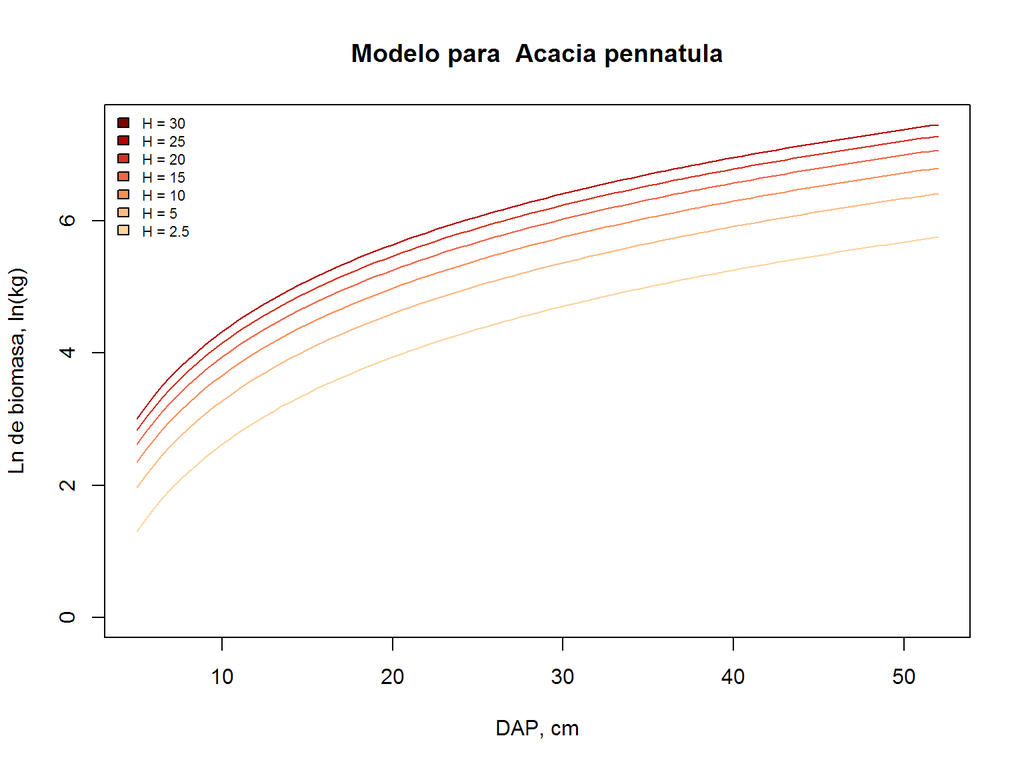

```
##
## [1] "Acacia schaffneri"
## Formula:  exp(-3.282 + 0.95 * log((DAP^2) * H))
```

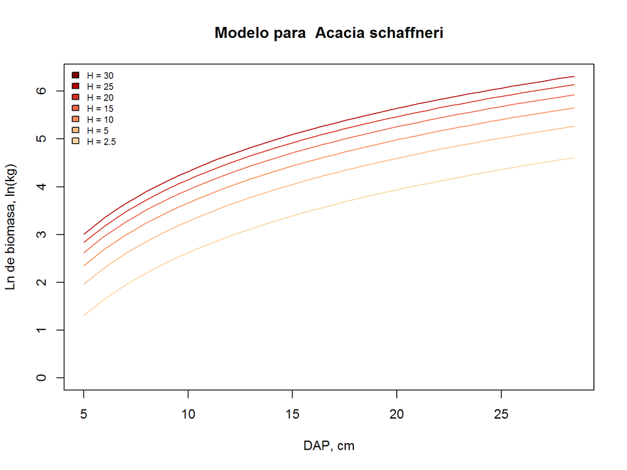

```
##
## [1] "Araucaria heterophylla"
## Formula:  430 * (0.0344 + 3e-05 * (DAP^2) * H)
```

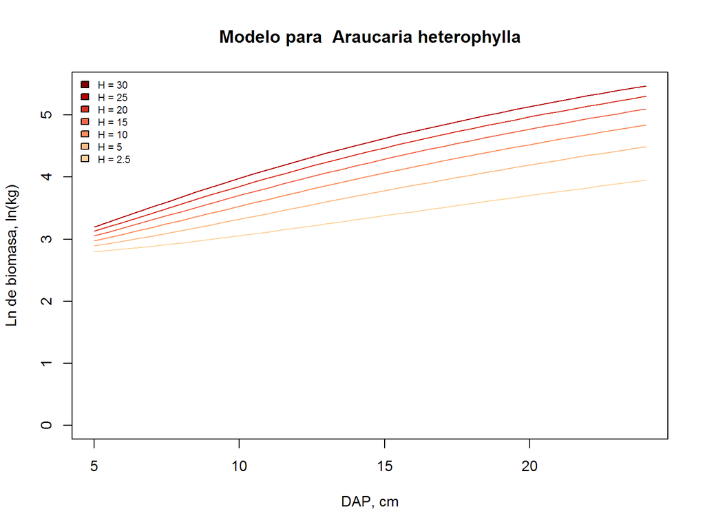

```
##
## [1] "Arecastrum romanzoffianum"
## Formula:  exp(-6.3789 - 0.877 * log(1/(DAP^2)) + 2.151 * log(H))
```

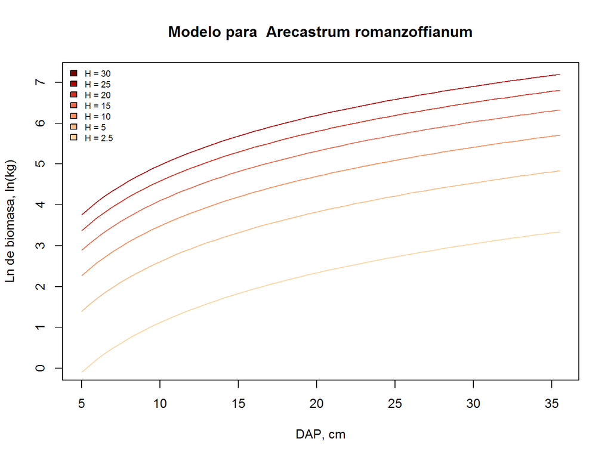

```
##
## [1] "Bauhinia variegata"
## Formula:  exp(-3.282 + 0.95 * log((DAP^2) * H))
```

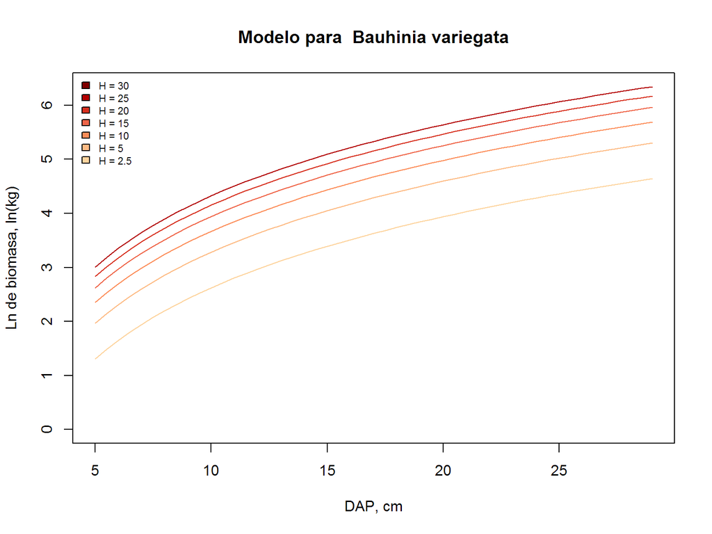

```
##
## [1] "Bucida buceras"
## Formula:  (0.85/0.65) * exp(-3.282 + 0.95 * log((DAP^2) * H))
```

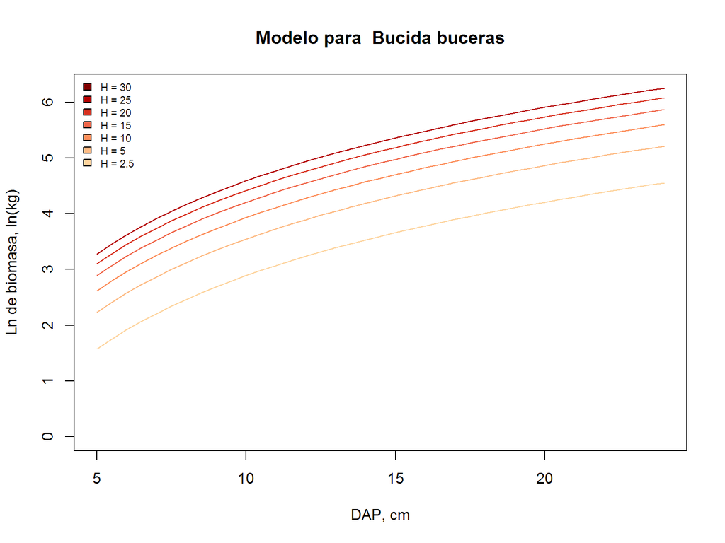

```
##
## [1] "Buddleja parviflora"
## Formula:  exp(-3.282 + 0.95 * log((DAP^2) * H))
```

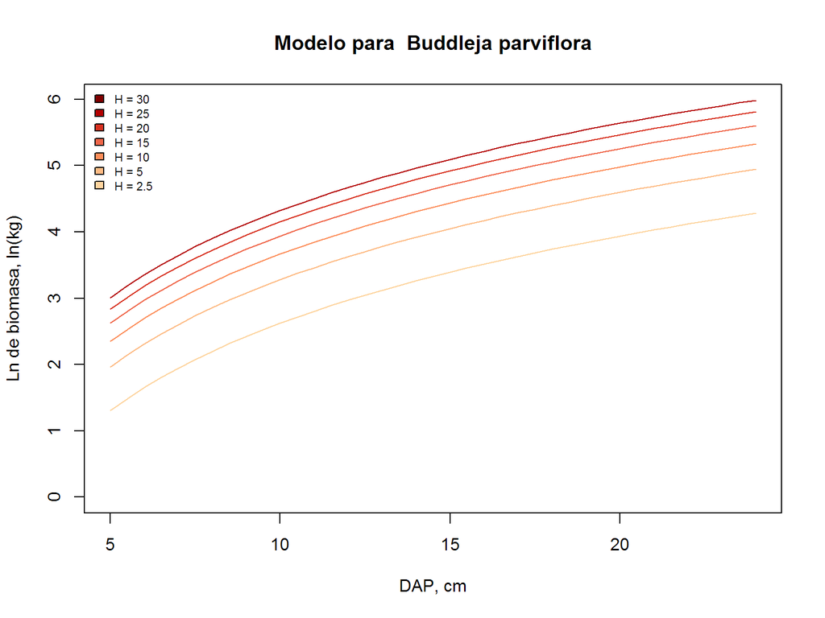

```
##
## [1] "Bursera fagaroides"
## Formula:  (0.43/0.65) * exp(-3.282 + 0.95 * log((DAP^2) * H))
```

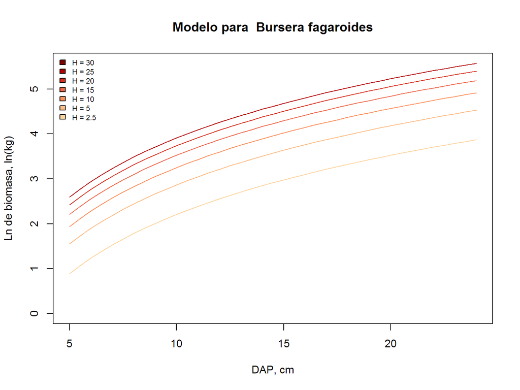

```
##
## [1] "Callistemon aff. salignus"
## Formula:  exp(-3.282 + 0.95 * log((DAP^2) * H))
```

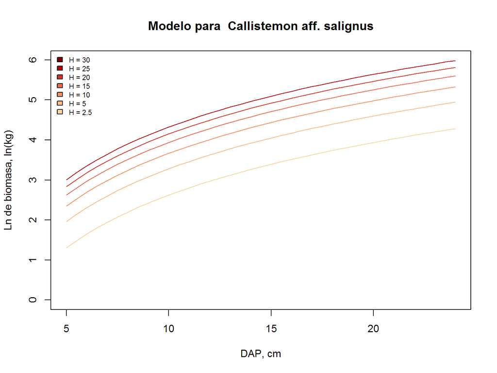

```
##
## [1] "Callistemon viminalis"
## Formula:  exp(-3.282 + 0.95 * log((DAP^2) * H))
```

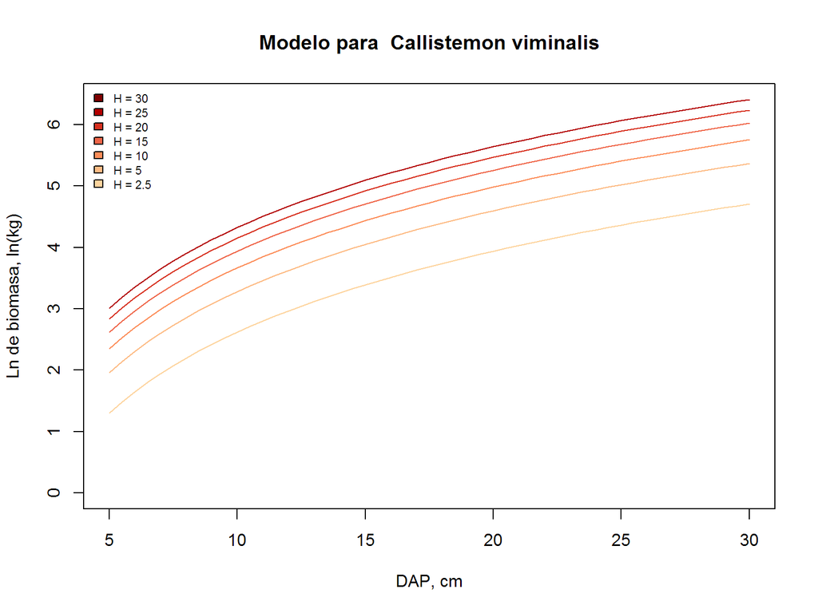

```
##
## [1] "Cascabela thevetioides"
## Formula:  exp(-3.282 + 0.95 * log((DAP^2) * H))
```

[49 more figures not shown]

```r
Hcolors <- brewer.pal(9, "OrRd")
Hcolors <- Hcolors[3:9]

for (i in 1:length(list_species)) {
  registros <- arboles_my[arboles_my$Especie == list_species[i],]
  formulaB <- formulasB[as.character(formulasB$Especie) == as.character(list_species[i]),]

  maxDAP <- max(registros$DAP)
  if (maxDAP < 20) { maxDAP <- 20 }
  seqH <- c(rev(seq(from = 5, to = 30, by = 5)),2.5)
  seqDAP <- seq(from = 5, to = 1.2 * maxDAP, by = 0.5)

  cat("\n")
  print(as.character(list_species[i]))
  formulaBeval <- parse(text=as.character(formulaB$Formula))
  cat(paste("Formula: ",formulaBeval,"\n"))

  DAP <- seqDAP
  H <- rep(seqH[1], times = length(seqDAP))
  seqBbase <- eval(formulaBeval)
  plot(seqDAP, log(seqBbase), type = "l",
       ylim = c(0, log(max(seqBbase))),
       main = paste("Modelo para ",as.character(list_species[i])),
       xlab = "DAP, cm", ylab = "Ln de biomasa, ln(kg)")

  for(iH in 1:length(seqH)) {
    H <- rep(seqH[iH], times = length(seqDAP))
    seqB <- eval(formulaBeval)
    lines(seqDAP, log(seqB), col = Hcolors[7 - iH])
  }

  legend("topleft", legend=paste("H =",seqH), bty="n", cex=.7, fill=rev(Hcolors))

}
```

#### Notas

Formulas genéricas: 1. Especies tropicales p = 0.65 - *Scatena* et al. (1989)  
2. Palmeras p = 0.52 - *Saldarriga* et al. (1988)  
3. Coniferas p = 0.54 *Palma* et al. 2001